# Second Source and Modeling

Brandon Walker

November 20, 2019

Firstly, we want to load everything we have done in the previous part.

```r
suppressMessages(suppressWarnings(library(tidyverse)))
suppressMessages(suppressWarnings(library(knitr)))
suppressMessages(suppressWarnings(library(caret)))
purl("Discovery_DataPrep.Rmd", output = "part1.r")
```

```
##
##
## processing file: Discovery_DataPrep.Rmd
```

[output not shown]

```
## output file: part1.r
```

```
## [1] "part1.r"
```

```r
capture.output(source("part1.r"), file='NUL')
```

## Second Datasource Introduction

Now since we have our previous data loaded, we can import a new dataset using an API. For this data source I am looking at salaries in the NYC area. I am using an API to limit the data I am recieving. Since It will only allow me to get 1000 rows in each call, I am going to use 4 different calls on 4 different base salary groups. The data will all be from the fiscal year 2017. This data source has a location, similar to the neighborhood_group in the airbnb dataset, for where they work so we can see if there is any relations with the price of airbnbs and where people make the most money.

```r
read1 <- read.csv("https://data.cityofnewyork.us/resource/k397-673e.csv?fiscal_year=2017&$where=base_salary>200000&$order=base_salary")
read2 <- read.csv("https://data.cityofnewyork.us/resource/k397-673e.csv?fiscal_year=2017&$where=base_salary>150000&$order=base_salary")
read3 <- read.csv("https://data.cityofnewyork.us/resource/k397-673e.csv?fiscal_year=2017&$where=base_salary>100000&$order=base_salary")
read4 <- read.csv("https://data.cityofnewyork.us/resource/k397-673e.csv?fiscal_year=2017&$where=base_salary>50000&$order=base_salary")


NYC_Salaries <- rbind(read1, read2, read3, read4)
```

```r
summary(NYC_Salaries)
```

```
##   fiscal_year   payroll_number                         agency_name
##  Min.   :2017   Mode:logical   DEPT OF ED PEDAGOGICAL        :1014
##  1st Qu.:2017   NA's:3416      FIRE DEPARTMENT               : 900
##  Median :2017                  POLICE DEPARTMENT             : 344
##  Mean   :2017                  DEPARTMENT OF EDUCATION ADMIN : 118
##  3rd Qu.:2017                  DEPARTMENT OF SANITATION      :  91
##  Max.   :2017                  DEPT OF ENVIRONMENT PROTECTION:  73
##                                (Other)                       : 876
##      last_name      first_name      mid_init
##  BROWN    :  15   MICHAEL:  99          :1094
##  WILLIAMS :  14   JOHN   :  74   J      : 313
##  RODRIGUEZ:  13   JAMES  :  61   A      : 312
##  RIVERA   :  12   JOSEPH :  61   M      : 270
##  MARTINEZ :  11   ROBERT :  54   R      : 139
##  FERNANDEZ:  10   THOMAS :  50   C      : 132
##  (Other)  :3341   (Other):3017   (Other):1156
##                agency_start_date   work_location_borough
##  2014-07-14T00:00:00.000: 272    MANHATTAN    :1759
##  2014-12-29T00:00:00.000: 265    BROOKLYN     : 571
##  2015-06-29T00:00:00.000: 252    QUEENS       : 477
##  2000-09-05T00:00:00.000:  75    OTHER        : 311
##  1999-09-07T00:00:00.000:  54    BRONX        : 186
##  2001-09-04T00:00:00.000:  54    RICHMOND     : 109
##  (Other)                :2444    (Other)      :   3
##                                                     title_description
##  FIREFIGHTER                                                 : 786
##  GUIDANCE COUNSELOR                                          : 379
##  PRINCIPAL                                                   : 354
##  CAPTAIN                                                     : 229
##  TEACHER                                                     : 180
##  COMPUTER SYSTEMS MANAGER                                    : 100
##  (Other)                                                     :1388
##        leave_status_as_of_july_31  base_salary                pay_basis
##  ACTIVE             :3039         Min.   : 50002    per Annum      :3403
##  CEASED             : 356         1st Qu.: 50173    per Hour       :   9
##  ON LEAVE           :  16         Median :100547    Prorated Annual:   4
##  ON SEPARATION LEAVE:   5         Mean   :115294
##                                   3rd Qu.:154229
##                                   Max.   :350000
##
##  regular_hours  regular_gross_paid    ot_hours       total_ot_paid
##  Min.   :   0   Min.   :-11240     Min.   :   0.00   Min.   :    0
##  1st Qu.:   0   1st Qu.: 50182     1st Qu.:   0.00   1st Qu.:    0
##  Median :1825   Median : 96900     Median :   0.00   Median :    0
##  Mean   :1253   Mean   :107104     Mean   :  99.74   Mean   : 4195
##  3rd Qu.:2086   3rd Qu.:156590     3rd Qu.: 148.72   3rd Qu.: 7408
##  Max.   :2086   Max.   :362416     Max.   :1215.37   Max.   :90379
##
##  total_other_pay
##  Min.   :-205816
##  1st Qu.:      0
##  Median :      0
##  Mean   :   2811
##  3rd Qu.:   3513
##  Max.   :  70000
##
```

```r
colnames(NYC_Salaries)
```

```
##  [1] "fiscal_year"                "payroll_number"
##  [3] "agency_name"                "last_name"
##  [5] "first_name"                 "mid_init"
##  [7] "agency_start_date"          "work_location_borough"
##  [9] "title_description"          "leave_status_as_of_july_31"
## [11] "base_salary"                "pay_basis"
## [13] "regular_hours"              "regular_gross_paid"
## [15] "ot_hours"                   "total_ot_paid"
## [17] "total_other_pay"
```

## Cleaning

As we can see from summary, the column payroll_number is all N/A’s so we can just remove that whole column. We can also see that middle initial has a lot of missing data, so I am also going to remove that column.

```r
NYC_Salaries <- NYC_Salaries[, !(names(NYC_Salaries) %in% c("payroll_number", "mid_init"))]
```

The agency_start_time column can be reduced down to just the date, since the time is always the same. I am going to parse the date and only keep that and get rid of the time.

```r
NYC_Salaries$agency_start_date <- parse_date(as.character(NYC_Salaries$agency_start_date), format = "%Y-%m-%dT00:00:00.000")
```

For this table I think its better to keep as one large table rather than splitting it up, because if we were to split it up, one table would only have agency name and the other table would have everything else.

I am going to change a couple of the column names since they are pretty long and can be shortend.

```r
colnames(NYC_Salaries)[colnames(NYC_Salaries) == "work_location_borough"] <- "work_location"
colnames(NYC_Salaries)[colnames(NYC_Salaries) == "leave_status_as_of_july_31"] <- "leave_status"
colnames(NYC_Salaries)[colnames(NYC_Salaries) == "agency_start_date"] <- "start_date"
```

## Visualization

Now we can visualize some of this data before we get into modeling.

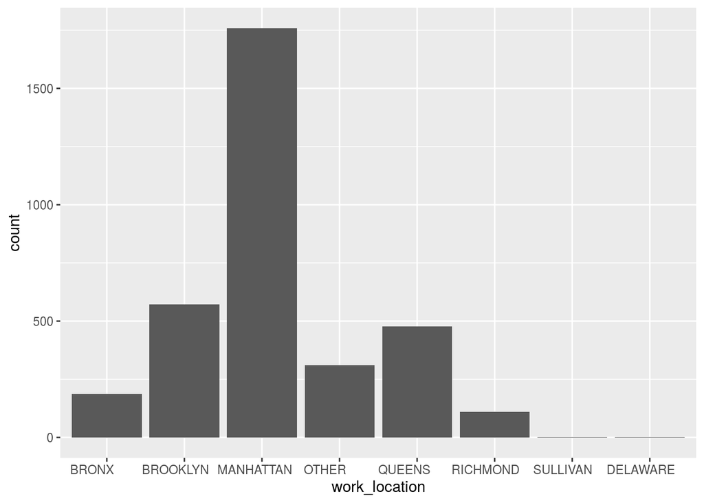

```r
ggplot(NYC_Salaries, aes(work_location)) + geom_bar()
```

As we can see, the majority of the work locations are in Manhattan.

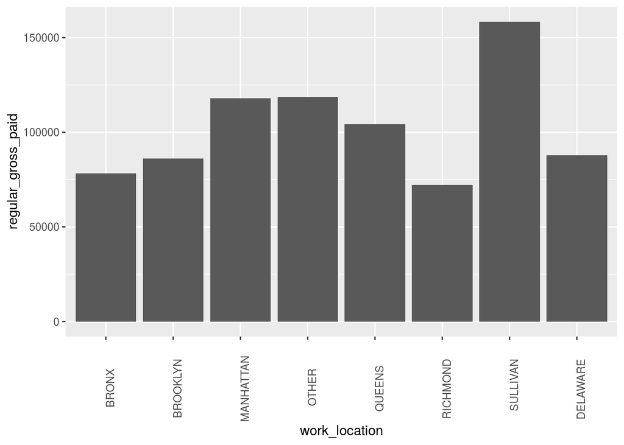

```r
ggplot(NYC_Salaries, aes(work_location, regular_gross_paid)) + stat_summary(fun.y = "mean", geom = "bar") + theme(axis.text.x = element_text(angle = 90, hjust = 1))
```

Based on our data we can see that Sullivan has the highest average regular gross paid, while Manhattan and Other are the other two highest. In contrast we can see that the Bronx and Richmond have the lowest average. This is interesting because in our last project, we could see that the Bronx has the lowest average priced airbnb’s.

## Modeling Airbnb Dataset

Now we can start Modeling:

First we are going to model data for the airbnb dataset, then we will model the nyc salaries dataset.

For my airbnb model I am going to try to find what are good predictors of an airbnb’s price. Since the airbnb data has some NA’s in important columns, we are going to use na.omit to remove the data with NA’s. We also have to convert our categorical variables to integers instead of being treated as a factor.

```r
airbnb <- na.omit(airbnb)
airbnb$neighbourhood <- as.integer(airbnb$neighbourhood)
airbnb$neighbourhood_group <- as.integer(airbnb$neighbourhood_group)
airbnb$room_type <- as.integer(airbnb$room_type)
```

We are now going to split the data into training and testing data. 80% of the data will be used to train the model then the test will be used to validate our model.

```r
index <- createDataPartition(airbnb$price, p=.80, list = F)
train = airbnb[index,]
test = airbnb[-index,]

train_airbnb <- lm(data = train, price ~ neighbourhood_group + neighbourhood + latitude + longitude + room_type + minimum_nights + number_of_reviews + reviews_per_month + availability_365)

summary(train_airbnb)
```

```
##
## Call:
## lm(formula = price ~ neighbourhood_group + neighbourhood + latitude +
##     longitude + room_type + minimum_nights + number_of_reviews +
##     reviews_per_month + availability_365, data = train)
##
## Residuals:
##    Min     1Q Median     3Q    Max
## -299.9  -53.7  -19.2   15.6 9945.2
##
## Coefficients:
##                       Estimate Std. Error t value Pr(>|t|)
## (Intercept)         -4.444e+04  2.009e+03 -22.124  < 2e-16 ***
## neighbourhood_group  8.773e+00  1.508e+00   5.817 6.04e-09 ***
## neighbourhood        7.808e-02  1.601e-02   4.877 1.08e-06 ***
## latitude             1.349e+02  2.072e+01   6.509 7.70e-11 ***
## longitude           -5.299e+02  2.371e+01 -22.350  < 2e-16 ***
## room_type           -9.577e+01  1.996e+00 -47.972  < 2e-16 ***
## minimum_nights      -1.635e-01  6.326e-02  -2.585  0.00976 **
## number_of_reviews   -1.976e-01  2.651e-02  -7.455 9.25e-14 ***
## reviews_per_month    1.406e-01  7.716e-01   0.182  0.85543
## availability_365     1.774e-01  8.525e-03  20.808  < 2e-16 ***
## ---
## Signif. codes:  0 '***' 0.001 '**' 0.01 '*' 0.05 '.' 0.1 ' ' 1
##
## Residual standard error: 186.9 on 31066 degrees of freedom
## Multiple R-squared:  0.1081, Adjusted R-squared:  0.1078
## F-statistic: 418.1 on 9 and 31066 DF,  p-value: < 2.2e-16
```

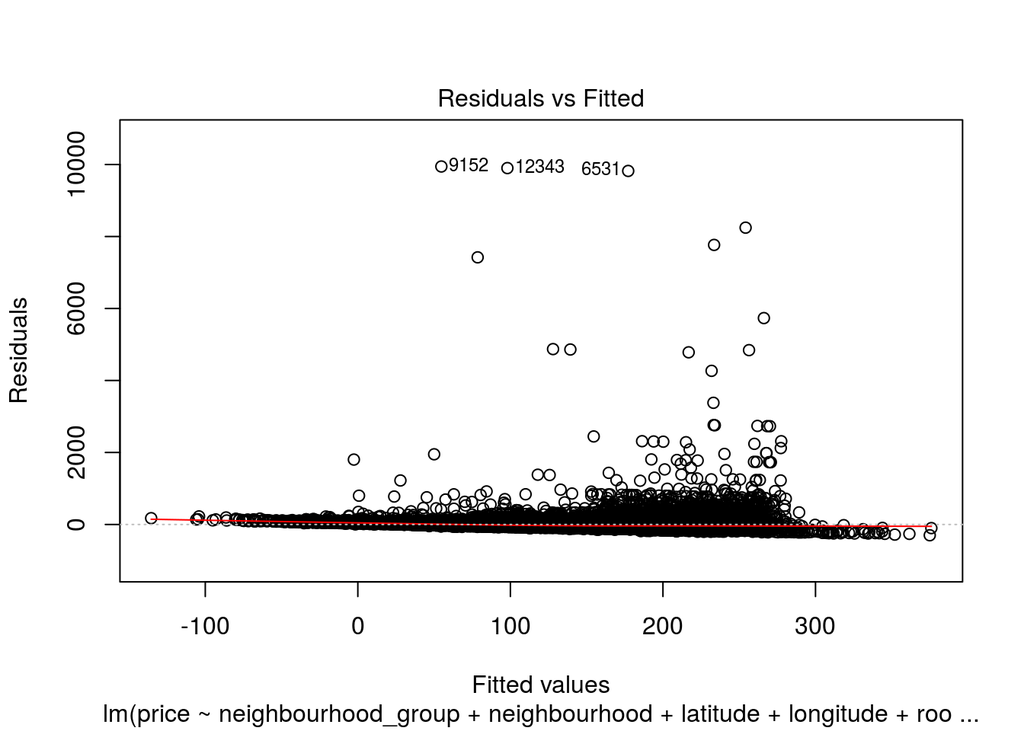

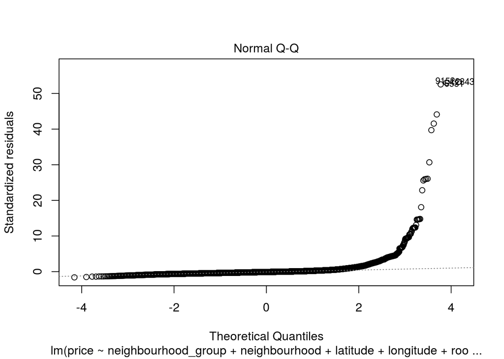

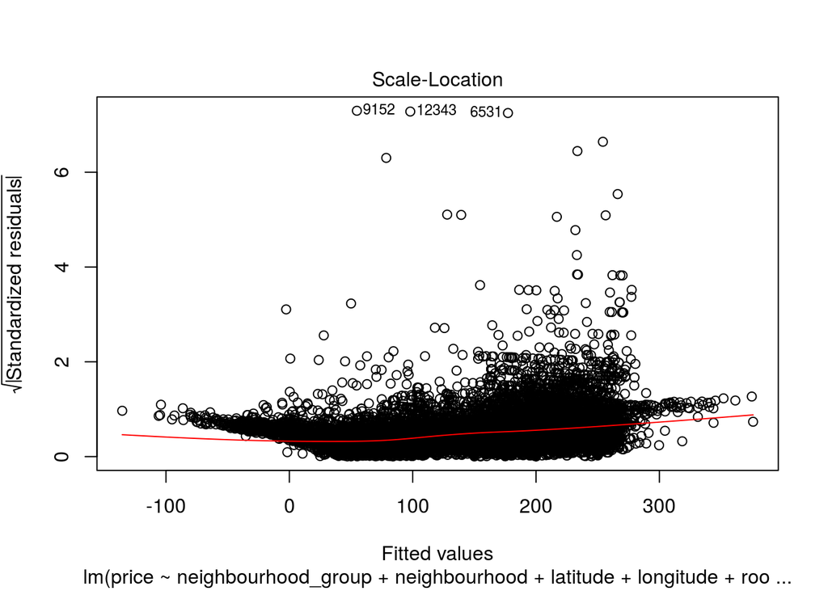

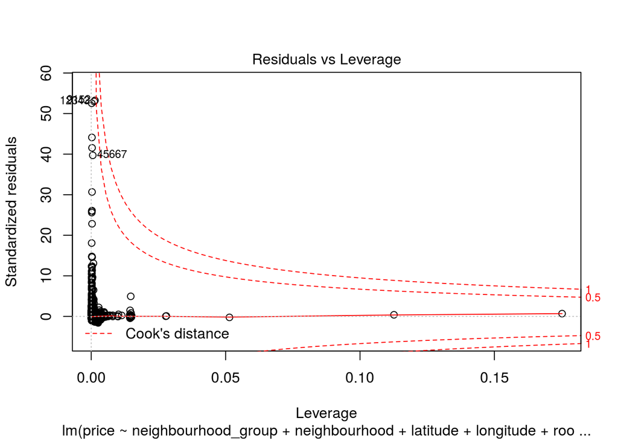

```r
plot(train_airbnb)
```

As we can see from the summary, everything except reviews per month are good predictors for the price of an airbnb in NYC. This makes sense because the first 4 are based on location, so if an area is more expensive to live in, then the price should be more expensive. Room type also makes sense because a whole apartment is going to cost more than a shared room. Minimum nights was not as good of a predictor and it makes sense because the minimum number of nights doesn’t seem like it should have an affect on the price. Number of reviews makes sense becuase a place with more reviews will probably be less expensive because more people can stay there. Availability is somewhat of a suprise to me because I wouldnt expect the availability to have an affect on the price.

Now we can validate our data on the test set.

```r
prediction <- train_airbnb %>% predict(test)
R2(prediction, test$price)
```

```
## [1] 0.1051779
```

```r
MAE(prediction, test$price)
```

```
## [1] 62.65726
```

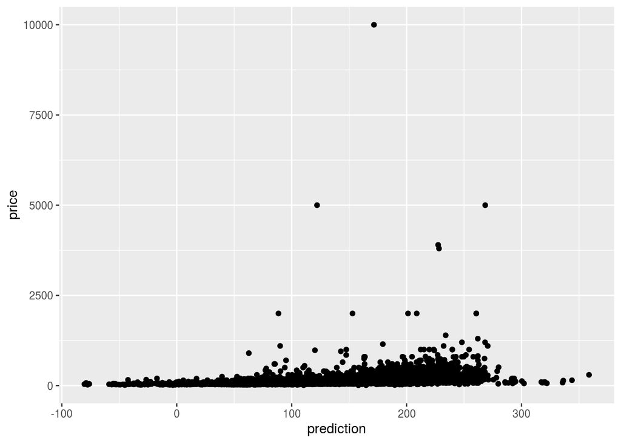

```r
ggplot(test, aes(prediction, price)) + geom_point()
```

```r
mean(test$price)
```

```
## [1] 141.5709
```

Our R2 value was pretty low, which means it wasnt able to fit the data very well.

## Modeling NYC Salaries Dataset

Now we are going to build a model for our NYC salaries dataset. We are going through the same steps so I will just label them rather than going into detail. We are going to try to predict the regular_gross_paid based on the variables. The only predictor I will use that is based on money is base_salary, otherwise it will just add up to get the gross_paid.

Fixing data types:

```r
NYC_Salaries$agency_name <- as.integer(NYC_Salaries$agency_name)
NYC_Salaries$work_location <- as.integer(NYC_Salaries$work_location)
NYC_Salaries$title_description <- as.integer(NYC_Salaries$title_description)
```

Splitting data and creating model:

```r
index <- createDataPartition(NYC_Salaries$regular_gross_paid, p=.80, list = F)
train = NYC_Salaries[index,]
test = NYC_Salaries[-index,]

train_nyc <- lm(data = train, regular_gross_paid ~ agency_name + start_date + work_location + title_description + base_salary + regular_hours)

summary(train_nyc)
```

```
##
## Call:
## lm(formula = regular_gross_paid ~ agency_name + start_date +
##     work_location + title_description + base_salary + regular_hours,
##     data = train)
##
## Residuals:
##     Min      1Q  Median      3Q     Max
## -193984   -2381    2322   17085   79203
##
## Coefficients:
##                     Estimate Std. Error t value Pr(>|t|)
## (Intercept)       -2.499e+04  4.717e+03  -5.297 1.27e-07 ***
## agency_name       -3.035e+02  4.323e+01  -7.020 2.79e-12 ***
## start_date        -4.703e-01  1.484e-01  -3.169 0.001549 **
## work_location      7.344e+02  4.541e+02   1.617 0.105971
## title_description  3.242e+01  9.758e+00   3.322 0.000904 ***
## base_salary        1.055e+00  1.689e-02  62.454  < 2e-16 ***
## regular_hours      1.522e+01  7.330e-01  20.770  < 2e-16 ***
## ---
## Signif. codes:  0 '***' 0.001 '**' 0.01 '*' 0.05 '.' 0.1 ' ' 1
##
## Residual standard error: 26970 on 2729 degrees of freedom
## Multiple R-squared:  0.8118, Adjusted R-squared:  0.8113
## F-statistic:  1961 on 6 and 2729 DF,  p-value: < 2.2e-16
```

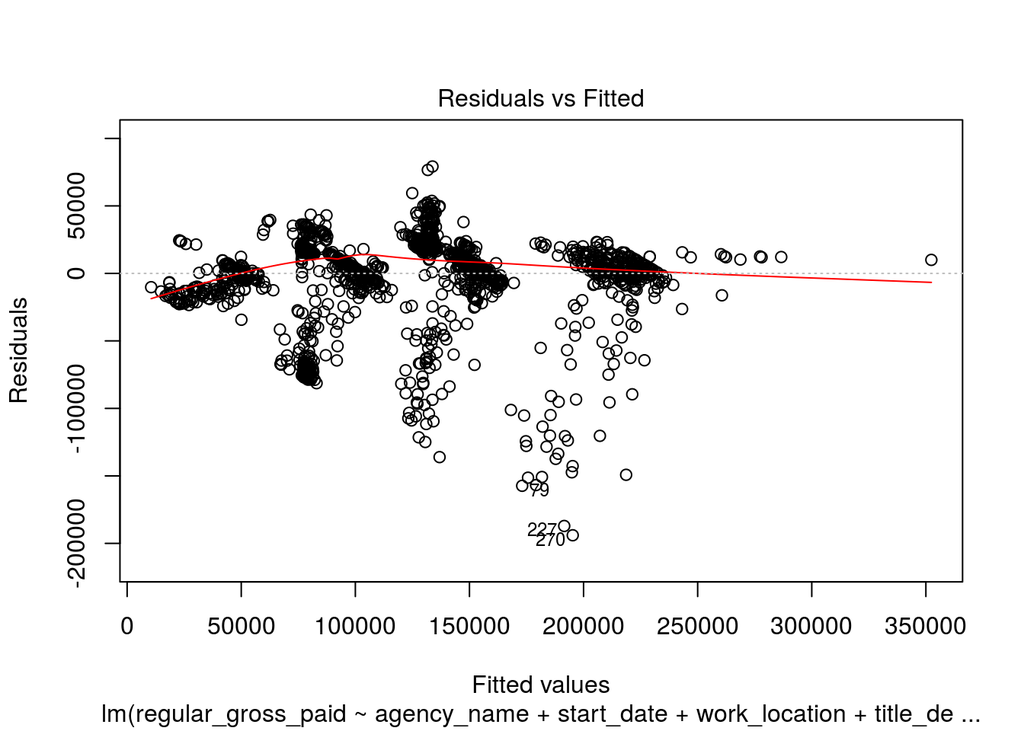

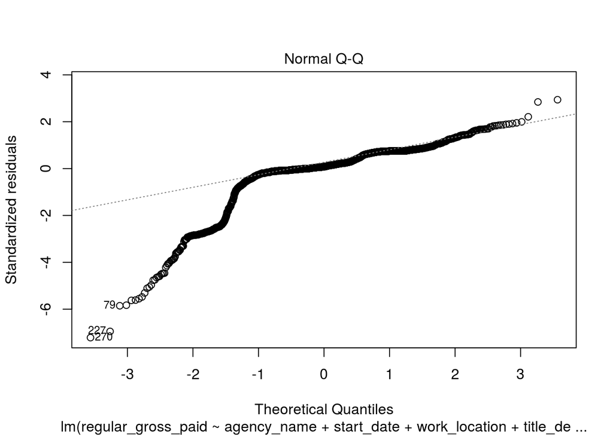

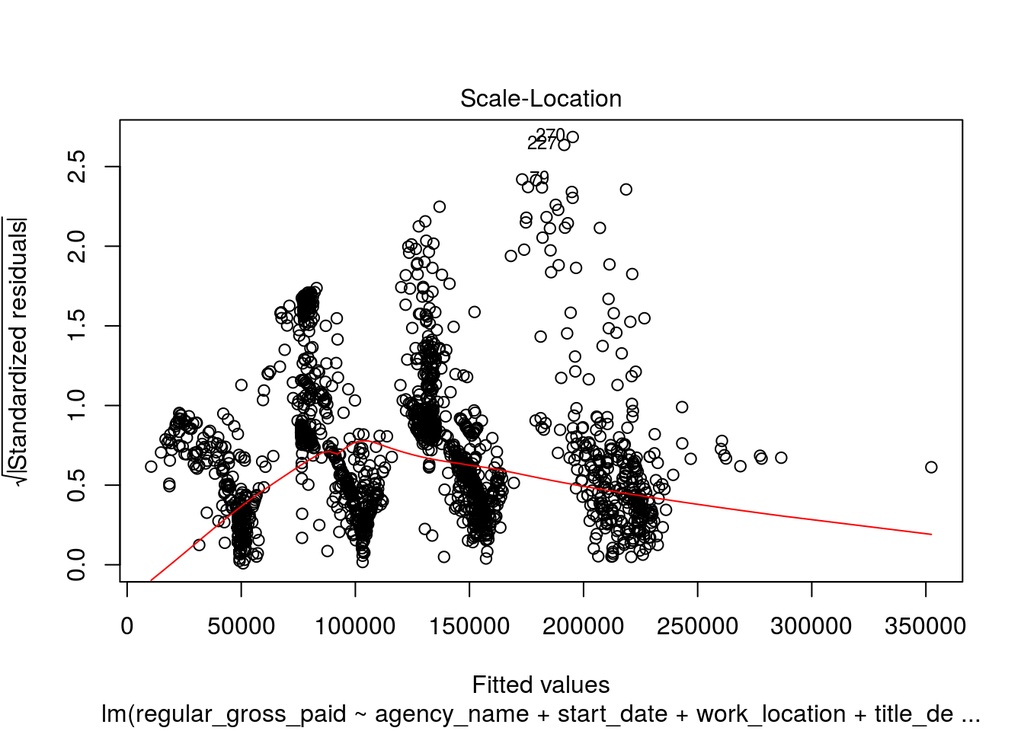

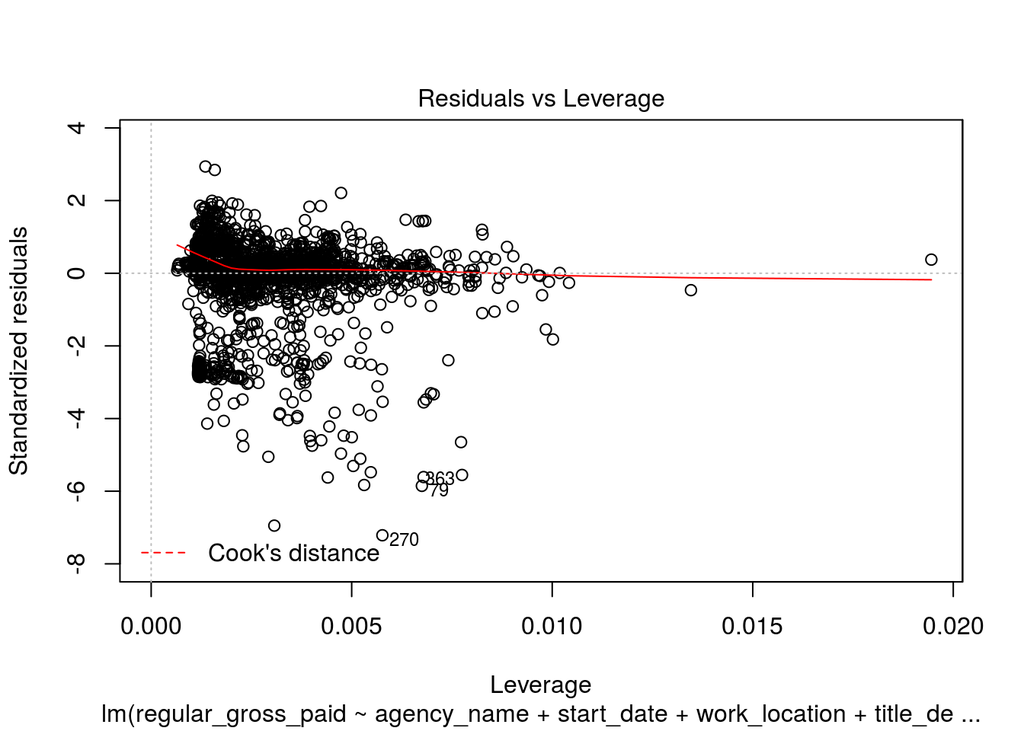

```r
plot(train_nyc)
```

As we can see from this summary, everything but work location are strong predictors. This seems interesting to me because I thought work location would be one of the strongest predictors. However this could be an error since so much data is from Manhatten, that there isnt enough difference for it to train on. As for agency name, this makes sense because some agency’s will pay more than others. Start date also makes sense because if you start later in the year then you will make less. Title description makes sense becasue pay is going to depend on your job and a software engineer is going to get paid more than a janitor. Base salary makes sense because if your base salary is more than your gross amount is going to be higher. Regular hours also makes sense because if you work more, then you are going to get paid more.

Validating data:

```r
prediction <- train_nyc %>% predict(test)
R2(prediction, test$regular_gross_paid)
```

```
## [1] 0.8206846
```

```r
MAE(prediction, test$regular_gross_paid)
```

```
## [1] 15026.58
```

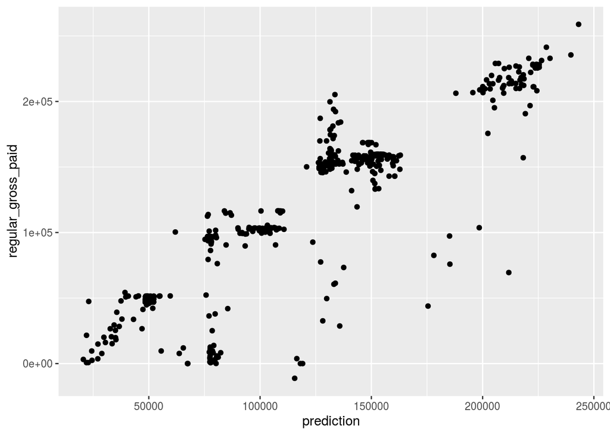

```r
ggplot(test, aes(prediction, regular_gross_paid)) + geom_point()
```

Our R2 value is about .80, which means that it was able to fit the data fairly well.